# Causal Inference - Exercise RD

Michael Knaus

SoSe 25

These are the goals of today:

- Run a Sharp RD analysis manually and using the `rdrobust` package
- Run a Fuzzy RD analysis replicating Huh and Reif (2021)

# Getting started

Load relevant packages

```
if (!require("estimatr")) install.packages("estimatr", dependencies = TRUE); library(estimatr)
if (!require("tidyverse")) install.packages("tidyverse", dependencies = TRUE); library(tidyverse)
if (!require("readxl")) install.packages("readxl", dependencies = TRUE); library(readxl)
if (!require("dplyr")) install.packages("dplyr", dependencies = TRUE); library(dplyr)
if (!require("haven")) install.packages("haven", dependencies = TRUE); library(haven)
if (!require("rdrobust")) install.packages("rdrobust", dependencies = TRUE); library(rdrobust)
```

With lots of plotting ahead, let’s set some `ggplot` defaults to save some space:

```
# Set the defaults for plotting:
custom_colors = c("royalblue", "coral")

# Set the default color scale for all plots
options(ggplot2.discrete.colour = custom_colors)
options(ggplot2.discrete.fill = custom_colors)

# Define a custom theme with modifications
custom_theme = theme_minimal() +
  theme(plot.title = element_text(face = "bold", hjust = 0.5, size = 14),
        legend.position = c(0.95, 0.16),
        legend.background = element_rect(fill = "white", color = "grey"),
        legend.text = element_text(face = "bold"),
        axis.title = element_text(size = 13))
theme_set(custom_theme)

# Define global aesthetics for common geoms
update_geom_defaults("point", list(size = 0.8, alpha = 0.3))
update_geom_defaults("vline", list(linewidth = 0.8))
update_geom_defaults("line", list(linewidth = 1.5))
update_geom_defaults("ribbon", list(fill = "grey30", alpha = 0.2))
labels = labs(x = "Winning margin last election", y = "Vote share")

# Custom annotation function
annotate_beta = function(coef_W) {annotate("text", x = 15, y = 50,
           label = bquote(hat(beta) == .(coef_W)), size = 4.5, fontface = "bold")}
```

## Load and prepare election data

This dataset contains information on elections for the U.S. Senate during the period 1914–2010. We focus on the RD effect of the Democratic party winning a U.S. Senate seat on the vote share in the following election for that same seat. The data set contains these two variables that are relevant for us:

- *vote* records the state-level vote share of the Democratic party in a given statewide election for a Senate seat (our $Y$)
- *margin* records the margin of victory of the Democratic party in the previous election for the same Senate seat (our $X$)

```
url = "https://raw.githubusercontent.com/rdpackages/rdrobust/master/R/rdrobust_senate.csv"
data = read.csv(url)
head(data)
```

|  | state | year | vote | margin | class | termshouse | termssenate | population |
| --- | --- | --- | --- | --- | --- | --- | --- | --- |
| 1 | 1 | 1914 | 36.09757 | -7.6885610 | 3 | 3 | 6 | 1233000 |
| 2 | 1 | 1916 | 45.46875 | -3.9237082 | 1 | 0 | 4 | 1294000 |
| 3 | 1 | 1922 | 45.59821 | -6.8686604 | 1 | 0 | 7 | 1431000 |
| 4 | 1 | 1926 | 48.47606 | -27.6680560 | 3 | 0 | 3 | 1531000 |
| 5 | 1 | 1928 | 51.74687 | -8.2569685 | 1 | 0 | 1 | 1577000 |
| 6 | 1 | 1932 | 39.80264 | 0.7324815 | 3 | 4 | 1 | 1637000 |

Define variables, in particular the treatment variable $W = 1[margin > 0]$ and collect the crucial variables into a tibble for later use:

```
Y = data$vote
X = data$margin
c = 0
W = as.factor((X > c) * 1)
xyw = tibble(X,Y,W)
```

## First descriptives

Plot the running variable

```
xyw %>% ggplot(aes(x = X, fill = W)) +
  geom_histogram(binwidth = 5, color = "white", boundary = -100) +
  geom_vline(xintercept = 0) + labs(x = "Winning margin last election", y = "Count") +
  theme(legend.position = c(0.1, 0.85))
```

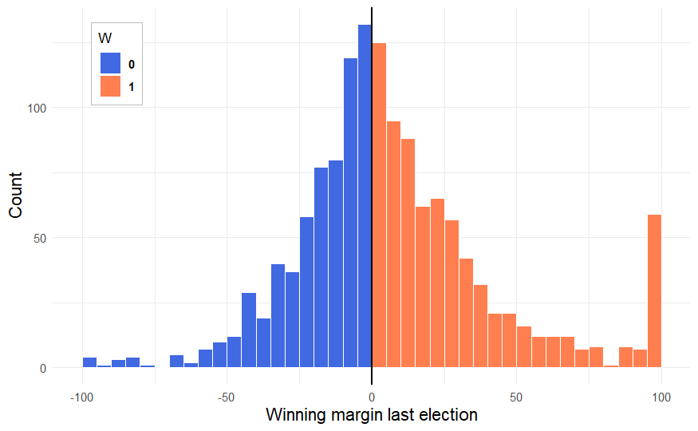

Run naive mean comparison:

```
summary(lm_robust(Y ~ W))
```

```
Call:
lm_robust(formula = Y ~ W)

Standard error type:  HC2

Coefficients:
            Estimate Std. Error t value   Pr(>|t|) CI Lower CI Upper   DF
(Intercept)    40.92     0.4990   82.01  0.000e+00    39.94    41.90 1295
W1             21.70     0.7918   27.41 8.139e-131    20.15    23.25 1295

Multiple R-squared:  0.3563 ,   Adjusted R-squared:  0.3558
F-statistic: 751.3 on 1 and 1295 DF,  p-value: < 2.2e-16
```

and plot what it does:

```
coef_W = round(coef(lm_robust(Y ~ W))["W1"], 2)
xyw %>% ggplot(aes(x = X, y = Y, color = W)) +  geom_point() +
  stat_smooth(method = 'lm', formula = y ~ 1, linewidth = 1.5) +
  geom_vline(xintercept = 0) + annotate_beta(coef_W) + labels +
  labs(title = "Naive mean comparison")
```

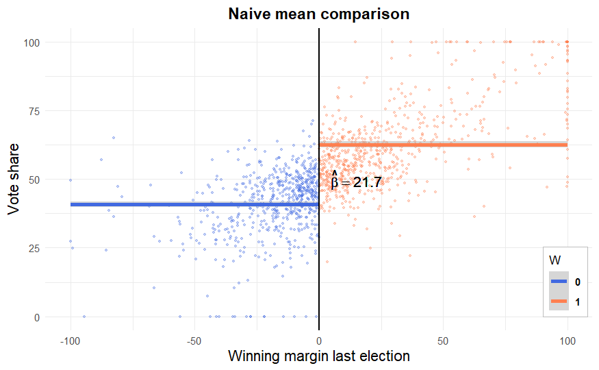

Why is this most likely not the causal effect of being an incumbent on the vote share? Do you think the effect is over- under underestimated?

# Manual implementation

## Local mean comparison

Set the bandwidth `h = 10` and run the local mean comparison:

```
h = 10
summary(lm_robust(Y ~ W,subset = (X > c - h & X < c + h)))
```

```
Call:
lm_robust(formula = Y ~ W, subset = (X > c - h & X < c + h))

Standard error type:  HC2

Coefficients:
            Estimate Std. Error t value   Pr(>|t|) CI Lower CI Upper  DF
(Intercept)   44.466     0.6283   70.77 1.156e-245   43.232    45.70 449
W1             9.622     0.8909   10.80  2.503e-24    7.871    11.37 449

Multiple R-squared:  0.2039 ,   Adjusted R-squared:  0.2021
F-statistic: 116.6 on 1 and 449 DF,  p-value: < 2.2e-16
```

and see what this would do graphically:

```
coef_W = round(coef(lm_robust(Y ~ W,subset = (X > c - h & X < c + h)))["W1"], 2)
xyw %>% ggplot(aes(x = X, y = Y, color = W)) +
  geom_point(size = 0.8, alpha = 0.3) +
  stat_smooth(data = filter(xyw, X<c&X>c-h),method = 'lm', formula = y ~ 1, linewidth = 2) +
  stat_smooth(data = filter(xyw, X>c&X<c+h),method = 'lm', formula = y ~ 1, linewidth = 2) +
  geom_vline(xintercept = 0) + annotate_beta(coef_W) + labels +
  labs(title = "Local mean comparison (h=10)")
```

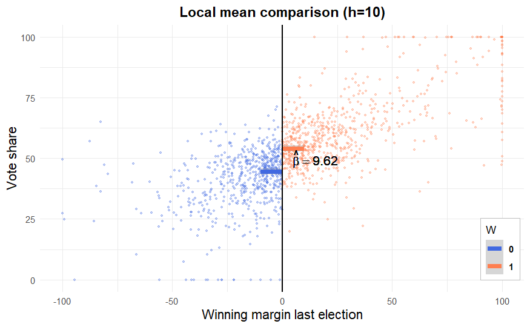

Run the local mean comparison for a grid of values (start with `h = 0.5`) and plot point estimates and confidence intervals along the grid.

```
h_seq = seq(0.5,100,0.5)
results_mat = matrix(rep(NA), nrow=length(h_seq), ncol = 2) #two columns: tau and s.e.

for (i in 1:length(h_seq)) {
  results_mat[i,1] = lm_robust(Y ~ W, subset = (X > c-h_seq[i] & X < h_seq[i]+c))$coefficients[2]
  results_mat[i,2] = lm_robust(Y ~ W, subset = (X > c-h_seq[i] & X < h_seq[i]+c))$std.error[2]
}

# Collect results:
tau = results_mat[,1]
se = results_mat[,2]
CI_upper = results_mat[,1]+1.96*results_mat[,2]
CI_lower = results_mat[,1]-1.96*results_mat[,2]

tibble(h_seq, tau, CI_lower, CI_upper) %>% ggplot(aes(x = h_seq, y = tau)) +
  geom_line(color = "indianred1", linetype ="solid", linewidth = 0.7) +
  geom_line(aes(x=h_seq, y = CI_lower), color = "cornflowerblue", linetype ="dashed", linewidth = 0.7) +
  geom_line(aes(x=h_seq, y = CI_upper), color = "cornflowerblue", linetype ="dashed", linewidth = 0.7) +
  labs(x = "Bandwidth parameter h", y = "tau") + geom_hline(yintercept = 0)
```

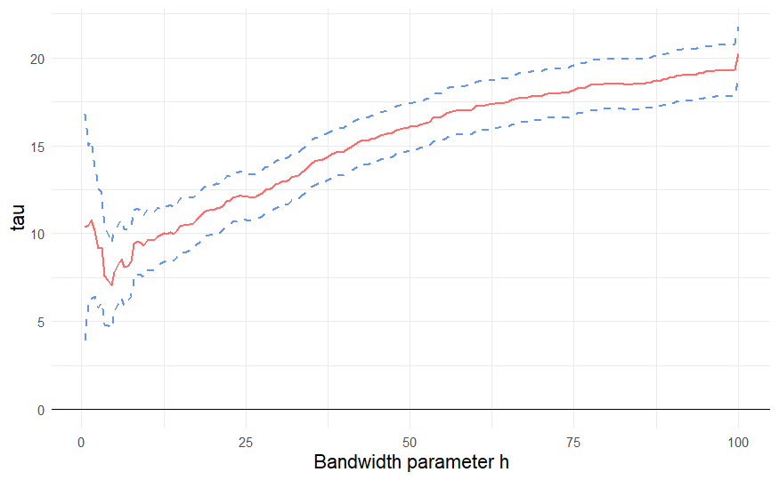

What do you observe?

## Global OLS with same slope on both sides

Run the OLS
$$Y = \alpha + \beta (X - c) +
\tau W + U$$

Usually you would need to define a centered running variable but in our case this is already done and we can just run

```
summary(lm_robust(Y ~ W + X))
```

```
Call:
lm_robust(formula = Y ~ W + X)

Standard error type:  HC2

Coefficients:
            Estimate Std. Error t value  Pr(>|t|) CI Lower CI Upper   DF
(Intercept)  47.3308    0.52637  89.919 0.000e+00  46.2982  48.3635 1294
W1            4.7846    0.86033   5.561 3.248e-08   3.0968   6.4724 1294
X             0.3481    0.01708  20.383 2.582e-80   0.3146   0.3816 1294

Multiple R-squared:  0.5781 ,   Adjusted R-squared:  0.5774
F-statistic: 590.5 on 2 and 1294 DF,  p-value: < 2.2e-16
```

Graphically it looks like this:

```
# Fit the linear model
model = lm(Y ~ W + X)

# Create a new data frame for prediction
new_data = data.frame(
  X = seq(min(X), max(X), length.out = length(X)),
  W = factor(as.numeric(seq(min(X), max(X), length.out = length(X)) >= 0)))

# Get predictions with confidence intervals
new_data[c("Y", "lwr", "upr")] = predict(model, newdata = new_data, interval = "confidence")

# Create the plot
coef_W = round(coef(lm_robust(Y ~ W + X))["W1"], 2)
ggplot(data, aes(x = X, y = Y)) + geom_point(aes(color = W)) +
  geom_line(data = data.frame(x = subset(new_data, X <= 0)$X, y = subset(new_data, X <= 0)$Y),
            aes(x = x, y = y), color = "coral") +
  geom_line(data = data.frame(x = subset(new_data, X > 0)$X, y = subset(new_data, X > 0)$Y),
            aes(x = x, y = y), color = "royalblue") +
  geom_ribbon(data = new_data, aes(x = X, y = Y, ymin = lwr, ymax = upr)) +
  geom_vline(xintercept = 0) + scale_color_manual(values = c("coral", "royalblue")) +
  labs(title = "Global OLS with Parallel Slopes") + labels + annotate_beta(coef_W)
```

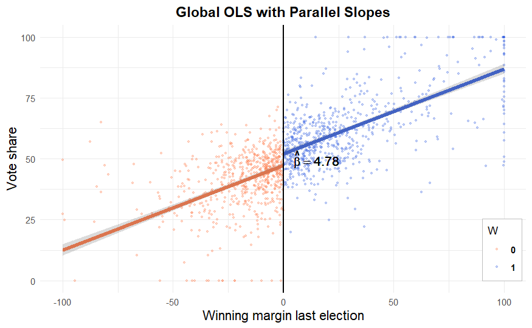

## Global OLS allowing for different slopes on each side

The previous specification is very restrictive. Maybe we want to allow at least for different slopes on each side of the cutoff #interactionterm.

Run the regression
$$Y = \alpha + \beta (X
- c) + \tau W + \gamma W * (X - c) + U$$

```
summary(lm_robust(Y ~ W + X + W * X))
```

```
Call:
lm_robust(formula = Y ~ W + X + W * X)

Standard error type:  HC2

Coefficients:
            Estimate Std. Error t value  Pr(>|t|) CI Lower CI Upper   DF
(Intercept)  44.9042    0.69888  64.251 0.000e+00 43.53317  46.2753 1293
W1            6.0440    0.89593   6.746 2.286e-11  4.28635   7.8016 1293
X             0.2163    0.03586   6.032 2.112e-09  0.14595   0.2867 1293
W1:X          0.1704    0.04015   4.245 2.347e-05  0.09166   0.2492 1293

Multiple R-squared:  0.5874 ,   Adjusted R-squared:  0.5864
F-statistic: 432.5 on 3 and 1293 DF,  p-value: < 2.2e-16
```

Graphically we do this:

```
coef_W = round(coef(lm_robust(Y ~ W + X + W * X))["W1"], 2)
xyw %>% ggplot(aes(x = X, y = Y, color = W)) +
  geom_point() +
  stat_smooth(method = 'lm', formula = y ~ x, linewidth = 1.5) +
  geom_vline(xintercept = 0) +
  labs(title = "Global OLS with different slopes") + labels + annotate_beta(coef_W)
```

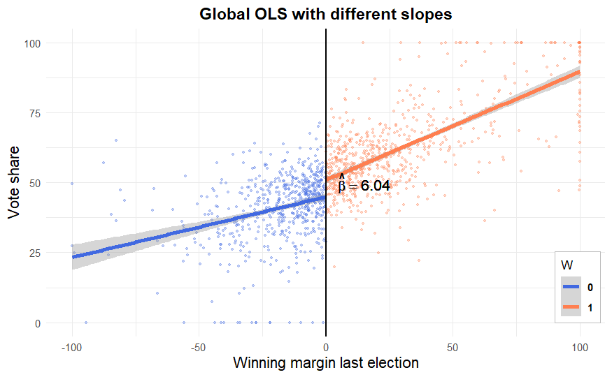

## Global polynomial

Now we check how the results change if you increase the order of polynomials.

Example with 2nd order polynomials

```
summary(lm_robust(Y ~ (W + poly(X,2,raw = T))^2 ))
```

```
Call:
lm_robust(formula = Y ~ (W + poly(X, 2, raw = T))^2)

Standard error type:  HC2

Coefficients:
                         Estimate Std. Error t value  Pr(>|t|)   CI Lower  CI Upper   DF
(Intercept)             46.739552   0.847333 55.1608 0.000e+00 45.0772512 4.840e+01 1291
W1                       4.934817   1.132522  4.3574 1.421e-05  2.7130308 7.157e+00 1291
poly(X, 2, raw = T)1     0.420629   0.080263  5.2406 1.867e-07  0.2631691 5.781e-01 1291
poly(X, 2, raw = T)2     0.003030   0.001274  2.3786 1.752e-02  0.0005309 5.529e-03 1291
W1:poly(X, 2, raw = T)1 -0.094709   0.098473 -0.9618 3.363e-01 -0.2878928 9.847e-02 1291
W1:poly(X, 2, raw = T)2 -0.002403   0.001408 -1.7070 8.805e-02 -0.0051639 3.586e-04 1291

Multiple R-squared:  0.5912 ,   Adjusted R-squared:  0.5896
F-statistic: 261.9 on 5 and 1291 DF,  p-value: < 2.2e-16
```

Plot:

```
coef_W = round(coef(lm_robust(Y ~ (W + poly(X,2,raw = T))^2 ))["W1"], 2)
xyw %>% ggplot(aes(x = X, y = Y, color = W)) + geom_point() +
  stat_smooth(method = 'lm', formula = y ~ poly(x,2,raw = T), linewidth = 1.5) +
  geom_vline(xintercept = 0) +
  labs(title = "Global polynomial") + labels + annotate_beta(coef_W)
```

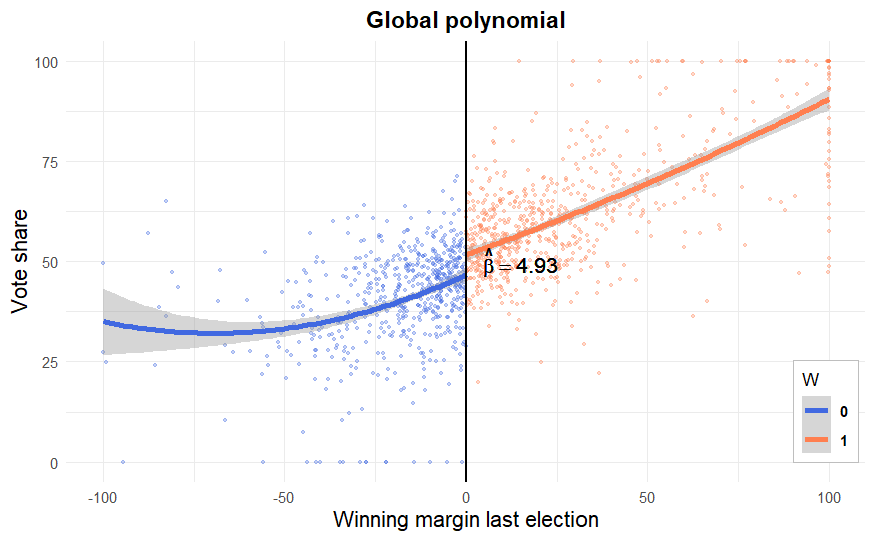

### (optional self-study) higher order polynomials

Increase the order of the polynomials and observe how the results change.

## Local linear

Now run a local linear regression with the bandwidth `h = 10`:

```
h = 10
summary(lm_robust(Y ~ (W + X)^2,subset = (X > c-h & X < h+c)))
```

```
Call:
lm_robust(formula = Y ~ (W + X)^2, subset = (X > c - h & X <
    h + c))

Standard error type:  HC2

Coefficients:
            Estimate Std. Error t value   Pr(>|t|) CI Lower CI Upper  DF
(Intercept)  45.3018     1.3746 32.9570 1.037e-121  42.6004  48.0033 447
W1            6.8988     1.7563  3.9280  9.918e-05   3.4472  10.3504 447
X             0.1702     0.2419  0.7039  4.819e-01  -0.3051   0.6456 447
W1:X          0.2275     0.3208  0.7093  4.785e-01  -0.4028   0.8579 447

Multiple R-squared:  0.2106 ,   Adjusted R-squared:  0.2053
F-statistic: 39.66 on 3 and 447 DF,  p-value: < 2.2e-16
```

```
coef_W = round(coef(lm_robust(Y ~ (W + X)^2,subset = (X > c-h & X < h+c)))["W1"], 2)
xyw %>% ggplot(aes(x = X, y = Y, color = W)) +
  geom_point() + geom_vline(xintercept = 0) +
  stat_smooth(data = filter(xyw, X<c&X>c-h),method = 'lm', formula = y ~ x, linewidth = 2) +
  stat_smooth(data = filter(xyw, X>c&X<c+h),method = 'lm', formula = y ~ x, linewidth = 2) +
  labs(title = "Local linear regression (h = 10)") + labels + annotate_beta(coef_W)
```

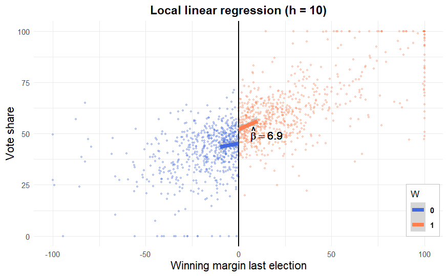

# Package implementation

The package [rdrobust](https://rdpackages.github.io/rdrobust/) (available for Python, R and Stata) is (to the best of my knowledge) the best maintained technology for RD analyses. It automates the optimal bandwidth search and comes with a lot of useful features (see their homepage).

It implements state-of-the-art bias correction and robust inference we have not the time to talk about but you should use if you had a real application:

```
summary(rdrobust(y=Y, x=X, all=TRUE))
```

```
Sharp RD estimates using local polynomial regression.

Number of Obs.                 1297
BW type                       mserd
Kernel                   Triangular
VCE method                       NN

Number of Obs.                  595          702
Eff. Number of Obs.             360          323
Order est. (p)                    1            1
Order bias  (q)                   2            2
BW est. (h)                  17.754       17.754
BW bias (b)                  28.028       28.028
rho (h/b)                     0.633        0.633
Unique Obs.                     595          665

=============================================================================
        Method     Coef. Std. Err.         z     P>|z|      [ 95% C.I. ]
=============================================================================
  Conventional     7.414     1.459     5.083     0.000     [4.555 , 10.273]
Bias-Corrected     7.507     1.459     5.146     0.000     [4.647 , 10.366]
        Robust     7.507     1.741     4.311     0.000     [4.094 , 10.919]
=============================================================================
```

This is the local linear regression using their bandwidth where the points are produced using the popular binscatter approach, i.e. the points are local averages, not real data points.

```
est = rdrobust(y=Y, x=X)

# Returning fancy design back to defaults for RDplot:
update_geom_defaults("point", list(size = 1.5, alpha = 1))
update_geom_defaults("line", list(linewidth = 0.8))

rdplot(y=Y, x=X, subset=-est$bws[1,1]<= X & X <= est$bws[1,2],
       binselect="esmv", kernel="triangular", h=c(est$bws[1,1], est$bws[1,2]), p=1,
       x.label = "Winning margin last election", y.label = "Vote share")
```

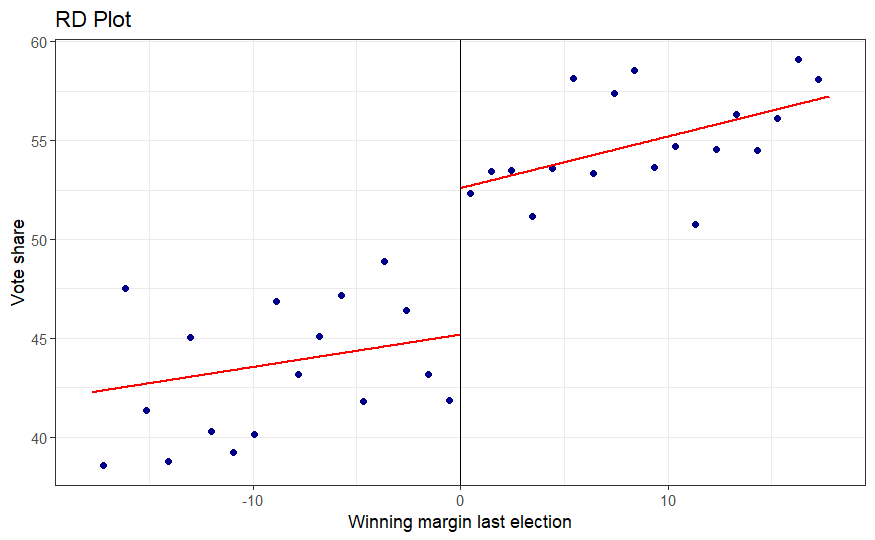

# Fuzzy RD

## Teenage Driving and Mortality ([Huh and Reif, 2021](https://www.aeaweb.org/articles?id=10.1257/aeri.20200653))

Teenage car accidents are responsible for over 60 percent of accidental deaths among adolescents—almost as common as suicides. Sifting through the causal relationship might be difficult, though: Teenagers who get their licenses right away might be different from those who wait. Perhaps the former are more risk-taking in general.

The paper we replicate looks closely at teenage driving and tries to figure out if getting a license actually causes an uptick in mortality and other risky behaviors.

There are two separate data sets we’ll be using:

1. *National Vital Statistics* (1983–2014) is based on death certificate records and includes information on month and year of death, cause of death, and state of residence of a person.

   Mortality is measured retrospectively, so deaths at different ages are recorded as they occur. The authors then combine these counts with population estimates to get age-specific mortality rate per 100,000 person-years, `cod_any` (our $Y$).
2. *The driving behaviors* (e.g., miles driven per week) are measured using a nationally representative sample of 20.000 students surveyed in 1995–1996. Same individuals were surveyed multiple times, so some of them aged across the threshold (before and after reaching driving age) and contributed to both sides.

   Our treatment variable $W$ is `DriverLicence`, a share of sample with driving licence.

```
# Load Adult Health data for teens behaviour
add_health = read_dta("https://julianreif.com/driving/data/add_health/derived/all.dta") %>%
  mutate(firstmonth = agemo_mda==0) # indicator: 1st month eligible to drive

# Load mortality data
df = read_dta("https://julianreif.com/driving/data/mortality/derived/all.dta") %>%
  mutate(firstmonth = agemo_mda==0,               # indicator: 1st month eligible to drive
         across(2:14, ~ . * 100000 / (pop / 12))) # deaths --> death rates
```

We wouldn’t expect any bunching here, since people cannot strategically alter their age to fall just above the cutoff:

```
ggplot(df, aes(x = agemo_mda, weight = pop)) +
  geom_histogram(binwidth = 5, color = "black", fill = "skyblue") +
  labs(title = "Distribution of the Running Variable", x = "Months until Allowed to Drive", y = "Frequency") +
  theme_minimal() + geom_vline(xintercept = 0, color = "#E41A1C") +
  theme(plot.title = element_text(size = 16, hjust = 0.5),
        axis.title = element_text(size = 14),
        panel.grid = element_line(color = "gray", linetype = "dotted", size = 0.5))
```

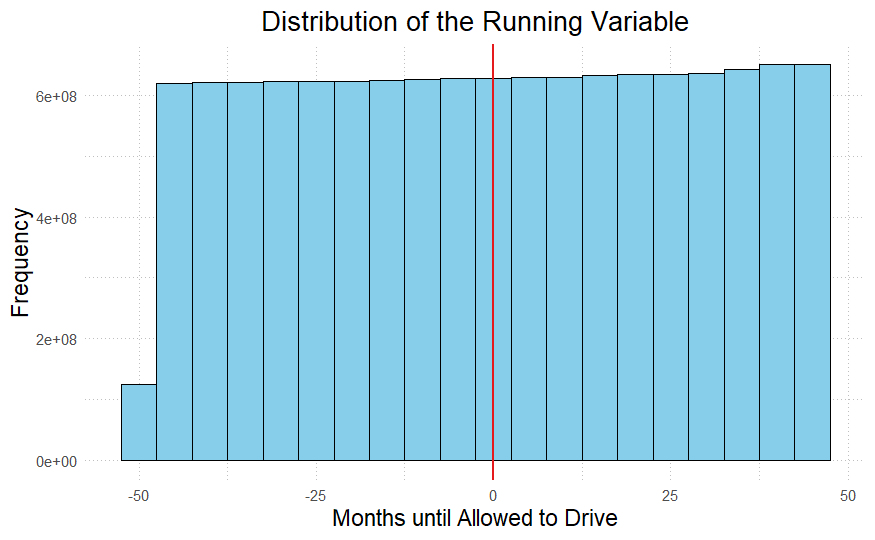

There is also no risk of sample selection because we observe the universe of deaths.

To identify the treatment effect, we need to make sure that the necessary assumptions hold.

First, the potential mortality rates $Y(0), Y(1)$ must be *continuous functions of age* at the MDA threshold:

$$\begin{align*}
\lim_{x \to c} \mathbb{E}[Y(0) \, | \, X = x] &= \mathbb{E}[Y(0) \,
| \, X = c] \\\
lim_{x \to c} \mathbb{E}[Y(1) \, | \, X = x] &= \mathbb{E}[Y(1) \, |
\, X = c]
\end{align*}$$

A teenager’s physical coordination, risk assessment abilities, and decision-making likely evolve smoothly around MDA.

Another assumption is *monotonicity*: the probability of receiving the treatment changes in a non-decreasing way:
$$\begin{equation*}
\lim_{x \downarrow c} \mathbb{E}[W \, | \, X = x] \geq \lim_{x
\uparrow c} \mathbb{E}[W \, | \, X = x],
\end{equation*}$$

There basically should be no teens who would get licenses when not eligible but wouldn’t when eligible. This seems sensible: legal incentives are aligned with compliance.

*First Stage Discontinuity*: There must be a meaningful jump in the probability of having a driver’s license at the MDA threshold. We’ll check that empirically in a moment.

The most challenging in our context is the *exclusion restriction*. It requires that crossing the minimum driving age (MDA) threshold affects mortality rates ($Y$) only through obtaining a driver’s license ($W$). In other words, reaching the minimum driving age should not affect teenage mortality through any channel other than the increased likelihood of having a driver’s license.

Several mechanisms might be at play here. For example, teens may get rides from newly licensed friends, or parents may become less restrictive once teens are legally eligible to drive, even for those who do not immediately get a license. This, in turn, leads them to participate in potentially risky activities.

If we think this setting is credible enough, the Conditional LATE (CLATE) at the cutoff can be identified as

$$\tau_{\text{LATE}} :=\mathbb{E}[Y(1)−Y(0)|T=c,X=c] = \dfrac{\lim_{X
\downarrow C}
\mathbb{E}\big[Y\mid X = x\big]-\lim_{X \uparrow c}
\mathbb{E}\big[Y\mid X=x\big]}{\lim_{X \downarrow c}
\mathbb{E}\big[W\mid X=x\big]-\lim_{X \uparrow c}
\mathbb{E}\big[W\mid X=x\big]}$$

And estimated in a familiar way.

An intuitively appealing bandwidth to start with could be 12 months. It is not far-fetched to assume that teenagers within a year of becoming eligible to drive are comparable. We can then see how far the MSE-optimal bandwidth is from our guess.

We also add an additional control variable: $C = \mathbf{1}[X=0]$. With monthly data, it is unclear whether someone who died in $X=0$ did so before or after actually becoming eligible to drive. Including the dummy accounts for this measurement uncertainty at the cutoff.

Start by checking how many people actually do get a licence:

```
bandwidth = 12

# Subset data within bandwidth h = 12
temp_df = add_health[abs(add_health$agemo_mda) <= bandwidth, ]

W = temp_df$DriverLicense
X = temp_df$agemo_mda
C = as.integer(temp_df$firstmonth)

# Fit separate regressions for left and right of the cutoff
lm_left  = lm(W ~ X + C, subset = X < 0)
lm_right = lm(W ~ X + C, subset = X >= 0)

firstStage = coef(lm_right)[1] - coef(lm_left)[1]
firstStage
```

```
(Intercept)
  0.1887567
```

And calculate how *becoming eligible to drive* affects death rate for the chosen age group

```
temp_df = df[abs(df$agemo_mda) <= bandwidth, ]

Y = temp_df$cod_any
X = temp_df$agemo_mda
C = as.integer(temp_df$firstmonth)

# Fit separate regressions for left and right of the cutoff
lm_left  = lm(Y ~ X + C, subset = X < 0)
lm_right = lm(Y ~ X + C, subset = X >= 0)

reducedForm = coef(lm_right)[1] - coef(lm_left)[1]
reducedForm
```

```
(Intercept)
   6.611472
```

Get the conditional LATE estimate as

```
reducedForm / firstStage
```

```
(Intercept)
   35.02643
```

Alternatively, we can rely on `rdrobust` and estimate both pieces optimally:

```
# First stage
W = add_health$DriverLicense
X = add_health$agemo_mda
C = as.integer(add_health$firstmonth)

firstStageMSE = rdrobust(W, X, covs = C)
summary(firstStageMSE)
```

```
Covariate-adjusted Sharp RD estimates using local polynomial regression.

Number of Obs.                   96
BW type                       mserd
Kernel                   Triangular
VCE method                       NN

Number of Obs.                   48           48
Eff. Number of Obs.              12           13
Order est. (p)                    1            1
Order bias  (q)                   2            2
BW est. (h)                  12.738       12.738
BW bias (b)                  27.645       27.645
rho (h/b)                     0.461        0.461
Unique Obs.                      48           48

=============================================================================
        Method     Coef. Std. Err.         z     P>|z|      [ 95% C.I. ]
=============================================================================
  Conventional     0.186     0.025     7.346     0.000     [0.136 , 0.236]
        Robust         -         -     6.465     0.000     [0.124 , 0.231]
=============================================================================
```

```
# Reduced form
Y = df$cod_any
X = df$agemo_mda
C = as.integer(df$firstmonth)

reducedFormMSE = rdrobust(Y, X, covs = C)
summary(reducedFormMSE)
```

```
Covariate-adjusted Sharp RD estimates using local polynomial regression.

Number of Obs.                   96
BW type                       mserd
Kernel                   Triangular
VCE method                       NN

Number of Obs.                   48           48
Eff. Number of Obs.              10           11
Order est. (p)                    1            1
Order bias  (q)                   2            2
BW est. (h)                  10.534       10.534
BW bias (b)                  16.256       16.256
rho (h/b)                     0.648        0.648
Unique Obs.                      48           48

=============================================================================
        Method     Coef. Std. Err.         z     P>|z|      [ 95% C.I. ]
=============================================================================
  Conventional     5.844     1.569     3.725     0.000     [2.769 , 8.919]
        Robust         -         -     3.018     0.003     [1.990 , 9.364]
=============================================================================
```

And plot them:

```
rdplot(W, add_health$agemo_mda, c = 0, p = 1, binselect = "esmv", kernel = "triangular",
       h = c(firstStageMSE$bws[1,1], firstStageMSE$bws[1,2]), title = "First Stage",
       subset=-firstStageMSE$bws[1,1]<= X & X <= firstStageMSE$bws[1,2],
       x.label = "Minimum driving age", y.label = "Share with a licence")
```

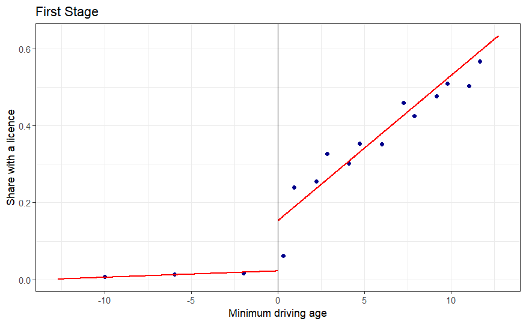

```
rdplot(Y, df$agemo_mda, c = 0, p = 1, binselect = "esmv", kernel = "triangular",
      h = c(reducedFormMSE$bws[1,1], reducedFormMSE$bws[1,2]), title = "Reduced Form",
       subset=-reducedFormMSE$bws[1,1]<= X & X <= reducedFormMSE$bws[1,2],
       x.label = "Minimum driving age", y.label = "All death")
```

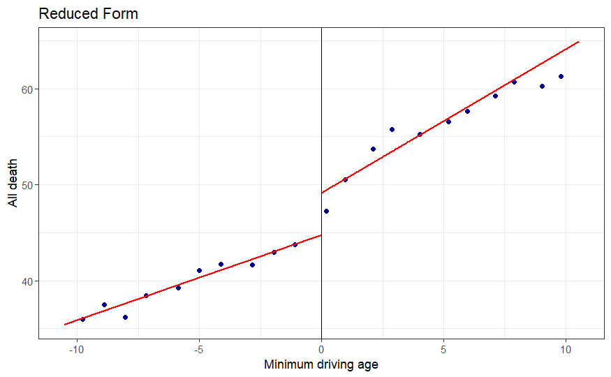

Comparing the estimates:

```
print(rbind("CLATE Estimate (h=12)" = reducedForm / firstStage,
      "CLATE Estimate (optimal h)"  = reducedFormMSE$Estimate[1] / firstStageMSE$Estimate[1]))
```

```
                           (Intercept)
CLATE Estimate (h=12)         35.02643
CLATE Estimate (optimal h)    31.39891
```

What is the interpretation of this *local* effect?

Scaling the all-cause mortality estimate by the driver’s license estimate suggests that driving increases total mortality at the cutoff by 31.4 deaths per 100,000 (81 percent) among teenagers who get a license.

With this result in hand, what kind of policy recommendation can we suggest?

It’s not obvious. For example, raising the MDA could reduce the effect of eligibility on mortality if older teenagers are more careful drivers. On the other hand, it could increase the effect if older teenagers are more likely to drink and drive.

Can we interpret our findings as causal? The most common MDA during our sample period is 16, which brings up the possibility that the results are driven by a “birthday effect” or another regulation that takes effect at age 16, such as the federal minimum legal working age or a state’s minimum school-leaving age.

The first concern is ruled out because the discontinuities we observe are long-lasting. For the second one, we can check for discontinuities in the probability of working or leaving school at the MDA cutoff:

```
X = add_health$agemo_mda
C = as.integer(add_health$firstmonth)

# Not enrolled nor graduated
Y1  = add_health$Work4weeks
RD1 = rdrobust(Y1, X, covs = C)

# Not enrolled nor graduated
Y2  = add_health$NotEnrolled
RD2 = rdrobust(Y2, X, covs = C)

rdplot(Y1, X, c = 0, p = 1, binselect = "esmv", kernel = "triangular",
       h = c(RD1$bws[1,1], RD1$bws[1,2]), title = "Work during last 4 weeks",
       subset=-RD1$bws[1,1]<= X & X <= RD1$bws[1,2],
       x.label = "Age in month relative to MDA", y.label = "Share Working")
```

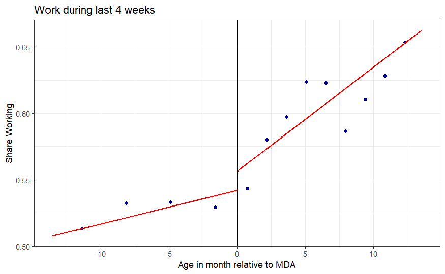

```
rdplot(Y2, X, c = 0, p = 1, binselect = "esmv", kernel = "triangular",
       h = c(RD2$bws[1,1], RD2$bws[1,2]), title = "Not enrolled nor graduated",
       subset=-RD2$bws[1,1]<= X & X <= RD2$bws[1,2],
       x.label = "Age in month relative to MDA", y.label = "Share Not Enrolled")
```

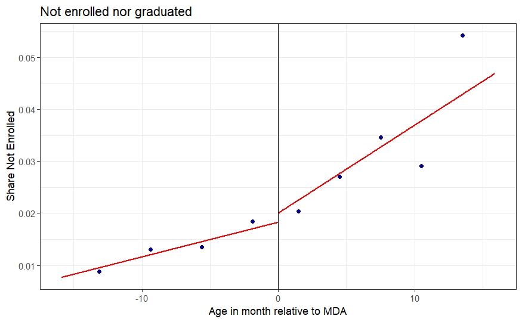

### (optional self-study)

1. Following the earlier analysis, we can study how sensitive the results are to the choice of bandwidth. Examine how the bandwidth selection impacts the estimates. You can use the graph from before by creating a handy, reusable function.
2. There are other causes of death in the dataset. The paper finds an unexpected result: female teenagers substitute away from firearms and toward drugs and gas poisoning when they gain access to a car. You can replicate this finding by doing a subgroup analysis.
3. It is common practice to estimate the model using placebo cutoffs. You can do this and check whether the estimates are centered around zero.